# PML Course Final Project

Harry Ramirez

May 25, 2019

## Summary

The goal of the project was to classify the way participants were doing an specific exercise by features created from the data of four sensors. Figure 1 shows were the sensors where attached. More details about how the data was recorded and features created can be found at [Qualitative Activity Recognition of Weight Lifting Exercises](http://web.archive.org/web/20170519033209/http://groupware.les.inf.puc-rio.br/public/papers/2013.Velloso.QAR-WLE.pdf).

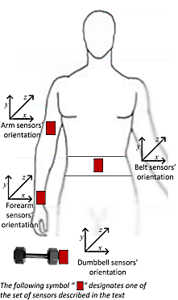

Figure 1

Our approach to complete the project was:

1. Download and explore the data
2. Clean the data
3. Select features
4. Select model type and parameters
5. Generate final model
6. Predict the test data

## Data Exploration

Data was downloaded from [training data](https://d396qusza40orc.cloudfront.net/predmachlearn/pml-training.csv) and [testing data](https://d396qusza40orc.cloudfront.net/predmachlearn/pml-testing.csv):

```r
trainingRaw <- read.csv("pml-training.csv", stringsAsFactors=FALSE)
testingRaw <- read.csv("pml-testing.csv", stringsAsFactors=FALSE)

dim(trainingRaw)
```

```
## [1] 19622   160
```

```r
table(sapply(trainingRaw, class))
```

```
##
## character   integer   numeric
##        37        35        88
```

```r
#head(trainingRaw, 1)

dim(testingRaw)
```

```
## [1]  20 160
```

```r
table(sapply(testingRaw, class))
```

```
##
## character   integer   logical   numeric
##         3        33       100        24
```

For some reason, a high amount of features were read as character or logic type when they were truly numeric. Our conclusion was that the data needed extensive cleaning in order to proceed.

## Data Cleaning

The following code was used to remove *“DIV/0!”* warnings withing the data. Columns with more than 95% unavailable values were identified.

```r
irrelevantCols <- names(trainingRaw)[1:7]
responseCol <- "classe"

nonNumericCols <- trainingRaw %>%
    select(-c(irrelevantCols, responseCol))
nonNumericCols <- names(nonNumericCols)[!sapply(nonNumericCols, is.numeric)]

# Convert to numeric data cols with data entry errors
for(i in nonNumericCols) {
    colValues <- trainingRaw[, i]
    print(i)
    print(table(colValues[colValues == "" | colValues == "#DIV/0!"]))
    cat("\n")
    colValues[colValues == ""] <- NA
    colValues[colValues == "#DIV/0!"] <- NA
    print(summary(as.numeric(colValues)))
    trainingRaw[, i] <- as.numeric(colValues)
    cat("\n\n")
}

# Find cols with more than 95% Na's
colsToCheck <- trainingRaw %>%
    select(-c(irrelevantCols, responseCol)) %>%
    names()
highNAsCols <- character()
for(i in colsToCheck) {
    naPercent <- mean(is.na(trainingRaw[, i]))
    print(paste0(i," Na's percent:", naPercent))
    if(naPercent > 0.95) {
        highNAsCols <- c(highNAsCols, i)
    }
    cat("\n")
}
```

Our decision was to discard columns with more than 95% unavailable values:

```r
length(highNAsCols)
```

```
## [1] 100
```

```r
training <- trainingRaw %>%
    select(-c(irrelevantCols, highNAsCols))

training$classe <- factor(training$classe)

testing <- testingRaw %>%
    select(-c(irrelevantCols, highNAsCols))

dim(training)
```

```
## [1] 19622    53
```

```r
table(sapply(training, class))
```

```
##
##  factor integer numeric
##       1      25      27
```

```r
head(training, 1)
```

```
##   roll_belt pitch_belt yaw_belt total_accel_belt gyros_belt_x gyros_belt_y gyros_belt_z accel_belt_x
## 1      1.41       8.07    -94.4                3            0            0        -0.02          -21
##   accel_belt_y accel_belt_z magnet_belt_x magnet_belt_y magnet_belt_z roll_arm pitch_arm yaw_arm
## 1            4           22            -3           599          -313     -128      22.5    -161
##   total_accel_arm gyros_arm_x gyros_arm_y gyros_arm_z accel_arm_x accel_arm_y accel_arm_z magnet_arm_x
## 1              34           0           0       -0.02        -288         109        -123         -368
##   magnet_arm_y magnet_arm_z roll_dumbbell pitch_dumbbell yaw_dumbbell total_accel_dumbbell gyros_dumbbell_x
## 1          337          516      13.05217        -70.494    -84.87394                   37                0
##   gyros_dumbbell_y gyros_dumbbell_z accel_dumbbell_x accel_dumbbell_y accel_dumbbell_z magnet_dumbbell_x
## 1            -0.02                0             -234               47             -271              -559
##   magnet_dumbbell_y magnet_dumbbell_z roll_forearm pitch_forearm yaw_forearm total_accel_forearm
## 1               293               -65         28.4         -63.9        -153                  36
##   gyros_forearm_x gyros_forearm_y gyros_forearm_z accel_forearm_x accel_forearm_y accel_forearm_z
## 1            0.03               0           -0.02             192             203            -215
##   magnet_forearm_x magnet_forearm_y magnet_forearm_z classe
## 1              -17              654              476      A
```

```r
dim(testing)
```

```
## [1] 20 53
```

```r
table(sapply(testing, class))
```

```
##
## integer numeric
##      29      24
```

The result of the data cleaning process was 52 features plus the outcome variable. Our next step was to evaluate how correlated were the independent variables.

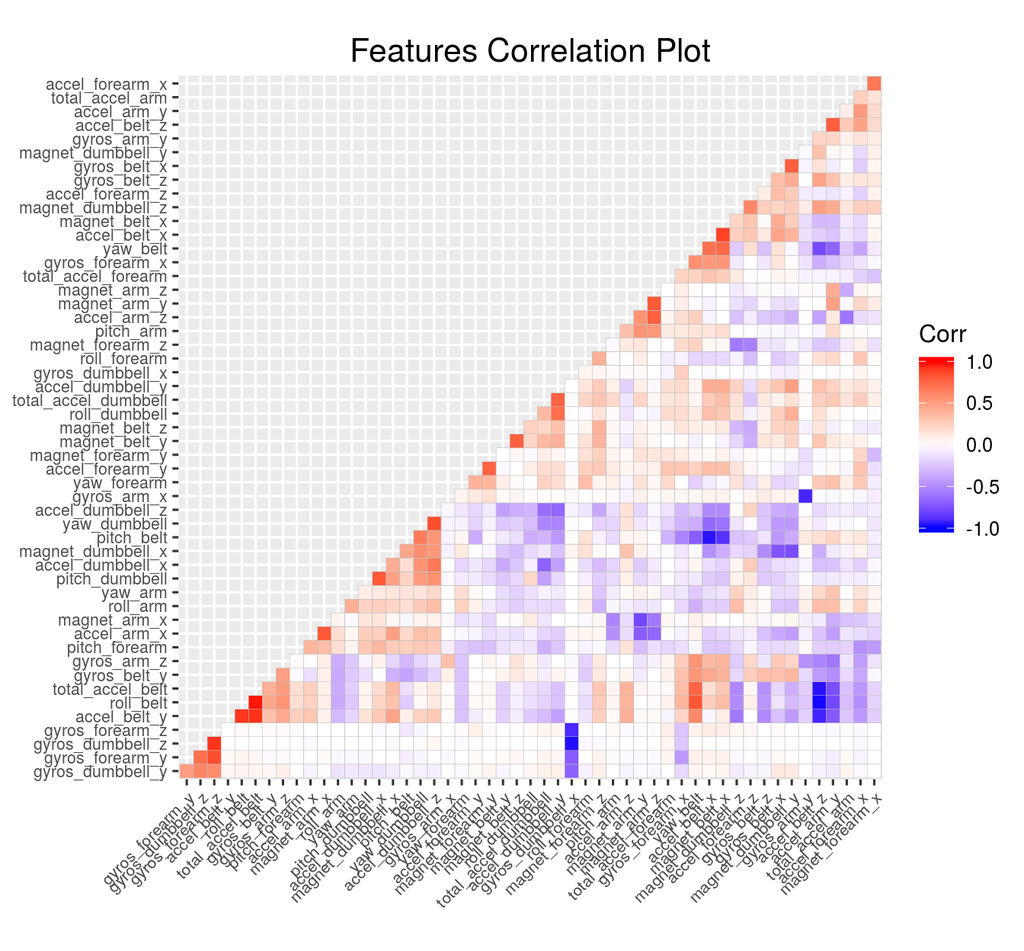

Since the chart showed high correlation between some variables and there was a large amount of features available, our strategy was to exclude features that had a correlation of over 0.80. Caret’s *findCorrelation* function was used:

```r
highlyCorr <- findCorrelation(cor(training[,-53]), cutoff = 0.80, verbose = F, names = T)

training <- training %>%
    select(-c(highlyCorr))

dim(training)
```

```
## [1] 19622    40
```

```r
names(training)
```

```
##  [1] "yaw_belt"             "total_accel_belt"     "gyros_belt_x"         "gyros_belt_y"
##  [5] "gyros_belt_z"         "magnet_belt_x"        "magnet_belt_y"        "magnet_belt_z"
##  [9] "roll_arm"             "pitch_arm"            "yaw_arm"              "total_accel_arm"
## [13] "gyros_arm_y"          "gyros_arm_z"          "accel_arm_y"          "accel_arm_z"
## [17] "magnet_arm_x"         "magnet_arm_z"         "roll_dumbbell"        "pitch_dumbbell"
## [21] "yaw_dumbbell"         "total_accel_dumbbell" "gyros_dumbbell_y"     "accel_dumbbell_y"
## [25] "magnet_dumbbell_x"    "magnet_dumbbell_y"    "magnet_dumbbell_z"    "roll_forearm"
## [29] "pitch_forearm"        "yaw_forearm"          "total_accel_forearm"  "gyros_forearm_x"
## [33] "gyros_forearm_z"      "accel_forearm_x"      "accel_forearm_y"      "accel_forearm_z"
## [37] "magnet_forearm_x"     "magnet_forearm_y"     "magnet_forearm_z"     "classe"
```

After removing the highly correlated variables, the result was 39 features plus the outcome variable. At this point the options were to include all 39 features on the prediction model or doing additional feature selection. The feature selection option was going to be time consuming in terms of coding and processing time. Several models needed to be evaluated, but there was a chance of getting better predictions on new data with a more parsimonious model.

## Feature Selection

We used a custom implementation of caret’s *rfe* function and random forest for feature selection. Since hundreds of models were evaluated, even with parallel processing, the code took overnight to run. Here is our code for Recursive Feature Elimination (RFE):

```r
library(caret)
library(recipes)

x <- training[, -ncol(training)]
y <- training[, ncol(training)]
x <- as.data.frame(x)

# Set rfe parameters
subsets <- c(15,17,19,21,23,25)

PickSizeTolerance002 <- function (x, metric, tol = 0.2, maximize) {
    pickSizeTolerance(x = x, metric = metric, tol = tol, maximize = maximize)
}

CaretFuncsFitForRecipes <- function (x, y, first, last, ...) {
    dots <- list(...)
    x <- as.data.frame(x)
    x$OUTCOME_VALS <- y
    trainRecipe <- recipe(OUTCOME_VALS ~ ., data = x)
    if (!is.null(dots$trRecipe)) {
        trainRecipe$steps <- dots$trRecipe$steps
        dots$trRecipe <- NULL
    }
    do.call(train, args = c(list(x = trainRecipe, data = x), dots))
}

myCaretFuncs <- caretFuncs
myCaretFuncs$fit <- CaretFuncsFitForRecipes
myCaretFuncs$selectSize <- PickSizeTolerance002

myRfeControl <- rfeControl(functions = myCaretFuncs,
                           rerank = T,
                           method = "repeatedcv",
                           number = 10,
                           repeats = 1,
                           verbose = TRUE,
                           allowParallel = FALSE) # works better if enabled on trainControl

myTrainCtrl <- trainControl(method = "repeatedcv",
                            number = 10,
                            repeats = 1,
                            search = "random",
                            allowParallel = TRUE)

myTrainRecipe <- recipe(OUTCOME_VALS ~., data = cbind(x, OUTCOME_VALS = y)[1:3,]) %>%
    step_center(all_predictors()) %>%
    step_scale(all_predictors())

# Init parallel processing parameters
library(doMC)
registerDoMC(cores = parallel::detectCores() - 1)

set.seed(10)
rfeResults <- rfe(x, y,
                 sizes = subsets,
                 rfeControl = myRfeControl,
                 method = "rf",
                 trRecipe = myTrainRecipe, # update recipe as necesarry
                 metric = "Accuracy",
                 maximize = TRUE,
                 trControl = myTrainCtrl,
                 tuneLength = 3,
                 importance = TRUE) # rf by default does not calculate importance

save(rfeResults, file = "rfeResults.rda")
```

RFE results were interesting and promising:

```r
load("rfeResults.rda")
rfeResults
```

```
##
## Recursive feature selection
##
## Outer resampling method: Cross-Validated (10 fold, repeated 1 times)
##
## Resampling performance over subset size:
##
##  Variables Accuracy  Kappa AccuracySD  KappaSD Selected
##         15   0.9919 0.9898   0.003096 0.003918
##         17   0.9927 0.9908   0.002495 0.003156
##         19   0.9927 0.9907   0.003011 0.003808
##         21   0.9940 0.9924   0.002078 0.002629        *
##         23   0.9934 0.9917   0.001927 0.002437
##         25   0.9932 0.9914   0.002507 0.003171
##         39   0.9955 0.9943   0.001137 0.001439
##
## The top 5 variables (out of 21):
##    yaw_belt, magnet_dumbbell_y, magnet_dumbbell_z, pitch_forearm, magnet_belt_y
```

```r
selectedFeatures <- predictors(rfeResults)
length(selectedFeatures)
```

```
## [1] 21
```

```r
selectedFeatures
```

```
##  [1] "yaw_belt"          "magnet_dumbbell_y" "magnet_dumbbell_z" "pitch_forearm"     "magnet_belt_y"
##  [6] "accel_dumbbell_y"  "gyros_belt_z"      "gyros_arm_y"       "yaw_arm"           "magnet_forearm_z"
## [11] "accel_forearm_x"   "roll_forearm"      "magnet_belt_z"     "roll_arm"          "magnet_arm_z"
## [16] "yaw_dumbbell"      "magnet_belt_x"     "magnet_forearm_y"  "pitch_arm"         "roll_dumbbell"
## [21] "accel_forearm_z"
```

Our strategy with RFE was not to select the most accurate model. Instead, the simplest model within a 0.2 tolerance of the most accurate was selected. The result was a 21 features model with a cross-validated accuracy of 0.9940.

## Prediction Models

Since accuracy on RFE using random forest was so high, we decided to continue using random forest as the model type for prediction. Part of the training data (i.e. 20%) was set apart for validation purposes. To have a better approximation of model’s accuracy using new data, a 10 fold cross-validation was used. This type of cross-validation preserved a balance between bias and variance during model’s parameter fine tuning.

```r
set.seed(123)
inValidationSubset <- createDataPartition(training$classe, p = 0.20, list = F)

myTrainCtrl1 <- trainControl(method = "repeatedcv",
                            number = 10,
                            repeats = 1,
                            search = "random",
                            allowParallel = TRUE)

myTrainRecipe <- recipe(classe ~., data = training[1:3,c(selectedFeatures, responseCol)]) %>%
    step_center(all_predictors()) %>%
    step_scale(all_predictors())

# Init parallel processing parameters
registerDoMC(cores = parallel::detectCores() - 2)
```

Here is the code for the first model we trained:

```r
set.seed(25)
train1 <- train(myTrainRecipe,
                data = training[-inValidationSubset, c(selectedFeatures, responseCol)],
                method = "rf",
                trControl = myTrainCtrl1,
                tuneLength = 3)

save(train1, file = "train1.rda")
```

The results using caret’s *search = “random”* were quite good:

```r
load(file = "train1.rda")
train1
```

```
## Random Forest
##
## 15695 samples
##    21 predictors
##     5 classes: 'A', 'B', 'C', 'D', 'E'
##
## Recipe steps: center, scale
## Resampling: Cross-Validated (10 fold, repeated 1 times)
## Summary of sample sizes: 14127, 14126, 14124, 14125, 14123, 14126, ...
## Resampling results across tuning parameters:
##
##   mtry  Accuracy   Kappa
##    4    0.9921637  0.9900870
##   15    0.9894882  0.9867022
##   19    0.9851557  0.9812217
##
## Accuracy was used to select the optimal model using the largest value.
## The final value used for the model was mtry = 4.
```

```r
validationPred1 <- predict(train1, training[inValidationSubset,])
mean(validationPred1 == training[inValidationSubset,responseCol])
```

```
## [1] 0.9933792
```

Bellow is the code for extra fine tuning on the *mtry* parameter:

```r
myTrainCtrl2 <- myTrainCtrl1
myTrainCtrl2$search = "grid"
myGrid <-  expand.grid(mtry = 4:6)
set.seed(25)
train2 <- train(myTrainRecipe,
                data = training[-inValidationSubset, c(selectedFeatures, responseCol)],
                method = "rf",
                trControl = myTrainCtrl2,
                tuneGrid = myGrid)

save(train2, file = "train2.rda")
```

By using *mtry = 5*, we were able to get an slightly better (0.9922273 vs. 0.9921637) cross-validation accuracy:

```r
load(file = "train2.rda")
train2
```

```
## Random Forest
##
## 15695 samples
##    21 predictors
##     5 classes: 'A', 'B', 'C', 'D', 'E'
##
## Recipe steps: center, scale
## Resampling: Cross-Validated (10 fold, repeated 1 times)
## Summary of sample sizes: 14127, 14126, 14124, 14125, 14123, 14126, ...
## Resampling results across tuning parameters:
##
##   mtry  Accuracy   Kappa
##   4     0.9917169  0.9895218
##   5     0.9922273  0.9901675
##   6     0.9917811  0.9896029
##
## Accuracy was used to select the optimal model using the largest value.
## The final value used for the model was mtry = 5.
```

```r
validationPred2 <- predict(train2, training[inValidationSubset,])
mean(validationPred2 == training[inValidationSubset,responseCol])
```

```
## [1] 0.9938885
```

A simpler model, using less trees for the random forest, may give better out of bag accuracy. Here is the code for fine tuning on the *ntree* parameter:

```r
set.seed(25)
train3 <- train(myTrainRecipe,
                data = training[-inValidationSubset, c(selectedFeatures, responseCol)],
                method = "rf",
                trControl = myTrainCtrl2,
                tuneGrid = myGrid,
                ntree = 150)

set.seed(25)
train4 <- train(myTrainRecipe,
                data = training[-inValidationSubset, c(selectedFeatures, responseCol)],
                method = "rf",
                trControl = myTrainCtrl2,
                tuneGrid = myGrid,
                ntree = 250)

save(train3, file = "train3.rda")
save(train4, file = "train4.rda")
```

Results for a simpler model using only 150 trees were more accurate (0.9924821 vs. 0.9922273) than caret’s default of 500 trees:

```r
load(file = "train3.rda") # 150 trees
train3
```

```
## Random Forest
##
## 15695 samples
##    21 predictors
##     5 classes: 'A', 'B', 'C', 'D', 'E'
##
## Recipe steps: center, scale
## Resampling: Cross-Validated (10 fold, repeated 1 times)
## Summary of sample sizes: 14127, 14126, 14124, 14125, 14123, 14126, ...
## Resampling results across tuning parameters:
##
##   mtry  Accuracy   Kappa
##   4     0.9913348  0.9890385
##   5     0.9924821  0.9904899
##   6     0.9919085  0.9897643
##
## Accuracy was used to select the optimal model using the largest value.
## The final value used for the model was mtry = 5.
```

```r
validationPred3 <- predict(train3, training[inValidationSubset,])
mean(validationPred3 == training[inValidationSubset,responseCol])
```

```
## [1] 0.9933792
```

```r
load(file = "train4.rda") # 250 trees
train4
```

```
## Random Forest
##
## 15695 samples
##    21 predictors
##     5 classes: 'A', 'B', 'C', 'D', 'E'
##
## Recipe steps: center, scale
## Resampling: Cross-Validated (10 fold, repeated 1 times)
## Summary of sample sizes: 14127, 14126, 14124, 14125, 14123, 14126, ...
## Resampling results across tuning parameters:
##
##   mtry  Accuracy   Kappa
##   4     0.9914621  0.9891995
##   5     0.9920996  0.9900059
##   6     0.9917172  0.9895222
##
## Accuracy was used to select the optimal model using the largest value.
## The final value used for the model was mtry = 5.
```

```r
validationPred4 <- predict(train4, training[inValidationSubset,])
mean(validationPred4 == training[inValidationSubset,responseCol])
```

```
## [1] 0.9933792
```

The results from the previous models showed that a Random Forest with 150 trees and mtry between 4:5 was a good model for the application. Accuracies of over 99% were obtained on validation data and 10 fold cross-validation with these parameters.

We used all the original training data (aka. training + validation) to do some minor fine tunning prior to generating the final model, here is the code:

```r
modelTrainCtrl <- trainControl(method = "repeatedcv",
                            number = 10,
                            repeats = 1,
                            search = "grid",
                            allowParallel = TRUE)

modelGrid <-  expand.grid(mtry = 3:6)
set.seed(25)
trainAllData <- train(myTrainRecipe,
                data = training[, c(selectedFeatures, responseCol)],
                method = "rf",
                trControl = modelTrainCtrl,
                tuneGrid = modelGrid,
                ntree = 150,
                importance = TRUE)

save(trainAllData, file = "trainAllData.rda")
```

The best results (0.9939866) were obtained using *mtry = 4* and *ntree = 150*:

```r
load(file = "trainAllData.rda")
trainAllData
```

```
## Random Forest
##
## 19622 samples
##    21 predictors
##     5 classes: 'A', 'B', 'C', 'D', 'E'
##
## Recipe steps: center, scale
## Resampling: Cross-Validated (10 fold, repeated 1 times)
## Summary of sample sizes: 17659, 17660, 17659, 17661, 17659, 17659, ...
## Resampling results across tuning parameters:
##
##   mtry  Accuracy   Kappa
##   3     0.9936298  0.9919419
##   4     0.9939866  0.9923934
##   5     0.9936298  0.9919417
##   6     0.9938338  0.9922001
##
## Accuracy was used to select the optimal model using the largest value.
## The final value used for the model was mtry = 4.
```

## Final Prediction Model

Here is the code used to generate the final model using all the training data with parameters *mtry = 4* and *ntree = 150*:

```r
myTrainRecipe <- recipe(classe ~., data = training[1:3,c(selectedFeatures, responseCol)]) %>%
    step_center(all_predictors()) %>%
    step_scale(all_predictors())

modelTrainCtrl <- trainControl(method = "repeatedcv",
                            number = 10,
                            repeats = 3,
                            search = "grid",
                            allowParallel = TRUE)

modelGrid <-  expand.grid(mtry = 4)
set.seed(25)
finalModel <- train(myTrainRecipe,
                data = training[, c(selectedFeatures, responseCol)],
                method = "rf",
                trControl = modelTrainCtrl,
                tuneGrid = modelGrid,
                ntree = 150,
                importance = TRUE)

save(finalModel, file = "finalModel.rda")
```

A cross-validated accuracy of **0.9941** was obtained for the final model:

```r
load(file = "finalModel.rda")
finalModel
```

```
## Random Forest
##
## 19622 samples
##    21 predictors
##     5 classes: 'A', 'B', 'C', 'D', 'E'
##
## Recipe steps: center, scale
## Resampling: Cross-Validated (10 fold, repeated 3 times)
## Summary of sample sizes: 17659, 17660, 17659, 17661, 17659, 17659, ...
## Resampling results:
##
##   Accuracy   Kappa
##   0.9940886  0.9925225
##
## Tuning parameter 'mtry' was held constant at a value of 4
```

The following code extracts feature importance from the final model:

```r
varImportance <- varImp(finalModel)$importance %>%
    mutate(Feature = rownames(.)) %>%
    mutate(Overall = rowMeans(.[,-ncol(.)])) %>%
    mutate(Importance = Overall / sum(Overall) * 100) %>%
    arrange(desc(Importance)) %>%
    select(c("Feature", "Importance"))

varImportance
```

```
##              Feature Importance
## 1           yaw_belt  10.917661
## 2  magnet_dumbbell_y   8.829460
## 3  magnet_dumbbell_z   8.037899
## 4      pitch_forearm   5.562994
## 5   accel_dumbbell_y   5.364695
## 6      magnet_belt_y   4.896000
## 7        gyros_arm_y   4.832303
## 8       gyros_belt_z   4.439230
## 9      magnet_belt_z   4.374421
## 10          roll_arm   4.331943
## 11      roll_forearm   4.206054
## 12  magnet_forearm_z   4.036991
## 13     magnet_belt_x   3.988169
## 14     roll_dumbbell   3.968510
## 15           yaw_arm   3.658788
## 16      yaw_dumbbell   3.590283
## 17  magnet_forearm_y   3.491316
## 18      magnet_arm_z   3.171801
## 19   accel_forearm_x   3.003430
## 20   accel_forearm_z   2.927271
## 21         pitch_arm   2.370781
```

Here is our prediction for the testing data:

```r
testPrediction <- data.frame(prediction = predict(finalModel, newdata = testing))
testPrediction <- cbind(testing[, ncol(testing), drop = FALSE], testPrediction)
# Next line was commented to hide quiz answers
#testPrediction
```